# 18장 modelr을 이용한 모델의 기초

```r
model1(c(7, 1.5), sim1)
```

```
##  [1]  8.5  8.5  8.5 10.0 10.0 10.0 11.5 11.5 11.5 13.0 13.0 13.0 14.5 14.5 14.5
## [16] 16.0 16.0 16.0 17.5 17.5 17.5 19.0 19.0 19.0 20.5 20.5 20.5 22.0 22.0 22.0
```

- 다음으로 예측된 값과 실제 값 사이의 전체 차이를 계산하는 방법이 필요하다. 다시 말하자면 플롯에서 나타내는 30개의 차이 값을 어떻게 하면 하나의 값으로 합칠 수 있을까?
- 통계학에서 이를 수행하는 일반적인 방법은 ‘평균제곱근 편차’를 사용하는 것이다. 실제값과 예측값의 차이를 제곱한 후 이 값들의 평균에 제곱근을 취한다.

```r
measure_distance <- function(mod, data) {
  diff <- data$y - model1(mod, data)
  sqrt(mean(diff ^ 2))
}
```

```r
measure_distance(c(7, 1.5), sim1)
```

```
## [1] 2.665212
```

- 이제 이전에 정의된 모든 모델의 차이를 계산하기 위해 purrr를 사용할 수 있다. 거리 차이를 계산하는 함수에서는 모델이, 길이가 2인 수치형 벡터 형식으로 입력되어야 하므로 도우미 함수가 필요하다. (purrr : 함수형 프로그래밍 도구)

```r
sim1_dist <- function(a1, a2) {
  measure_distance(c(a1, a2), sim1)
}
```

```r
models <- models %>%
  mutate(dist = purrr::map2_dbl(a1, a2, sim1_dist))
```

```r
models
```

```
## # A tibble: 250 x 3
##        a1     a2  dist
##     <dbl>  <dbl> <dbl>
##  1   4.09  2.25   2.41
##  2  34.6  -0.998 16.3
##  3  11.0   2.87  11.7
##  4 -19.2   0.136 34.4
##  5  -9.96 -1.84  37.4
##  6  19.9   0.503  8.74
##  7   4.19  4.39  14.6
##  8   7.73  3.58  12.9
##  9  29.4  -0.506 13.5
## 10  20.0  -1.19   9.77
## # ... with 240 more rows
```

- 다음으로 최적의 10가지 모델을 데이터에 겹쳐서 나타내보자, -dist를 사용해서 모델별로 색상을 지정했다. 이는 최적의 모델 (즉, 가장 차이가 적은 모델)을 가장 밝은 색상으로 나타낼 수 있는 쉬운 방법이다.

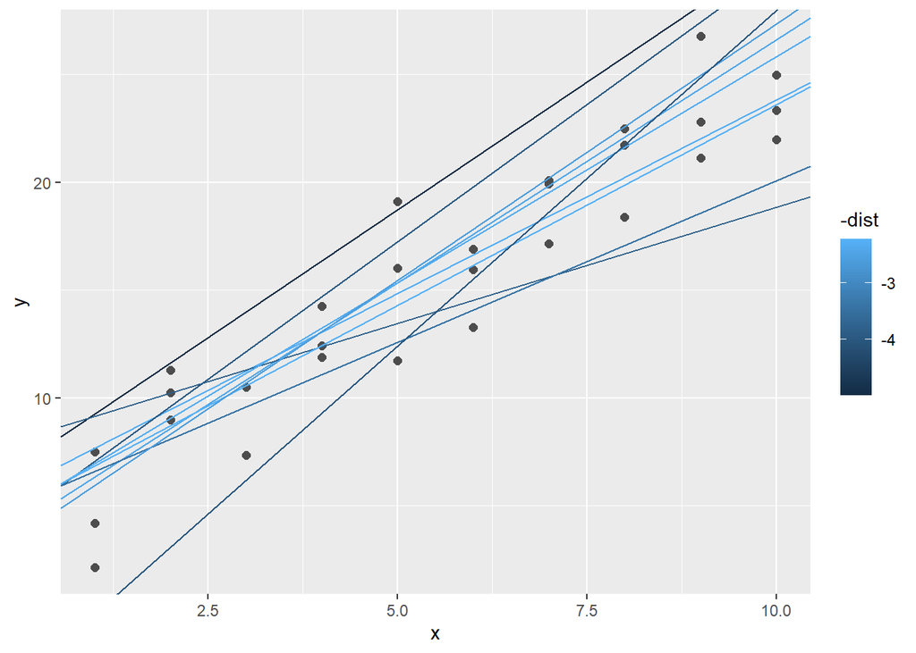

```r
ggplot(sim1, aes(x, y)) +
  geom_point(size = 2, color = "grey30") +
  geom_abline(
    aes(intercept = a1, slope = a2, color = -dist),
    data = filter(models, rank(dist) <= 10)
  )
```

- 또한, 모델을 관측값으로 간주하면 –dist로 동일하게 색상을 나타낸 a1과 a2의 산점도로 시각화할 수 있다. 데이터와 직접 비교한 모델은 확인할 수 없지만 한번에 여러 모델을 확인할 수 있다. 다시 말해 이전에는 가장 좋은 10개 모델만을 나타냈지만, 지금은 빨간색 원으로 10개의 모델을 강조했다.

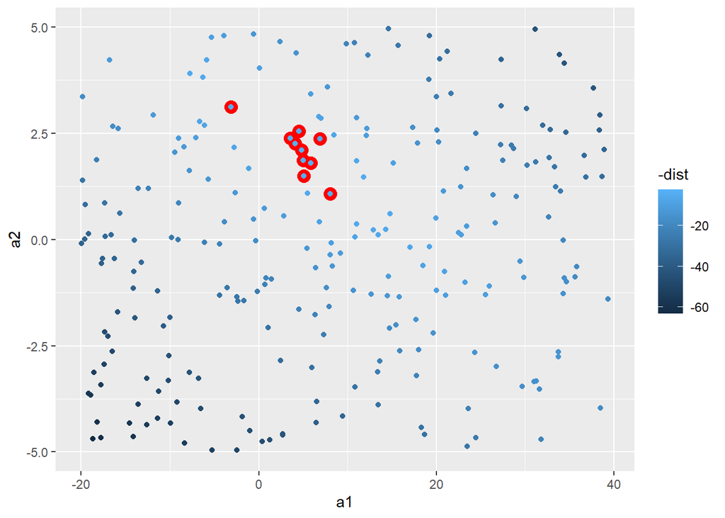

```r
ggplot(models, aes(a1, a2)) +
  geom_point(
    data = filter(models, rank(dist) <= 10),
    size = 4, color = "red"
  ) +
  geom_point(aes(colour = -dist))
```

- 랜덤한 모델을 많이 시도해 보는 체계적이고 균등하게 배치된 격자무늬의점(그리드 서치(grid search)라고 함)을 생성할 수 있다. 앞의 플롯에서 가장 좋은 모델이 어디에 있는지 대략 살펴보며 그리드 파라미터를 선택한다.

```r
grid <- expand.grid(
  a1 = seq(-5, 20, length = 25),
  a2 = seq(1, 3, length = 25)
) %>%
  mutate(dist = purrr::map2_dbl(a1, a2, sim1_dist))
```

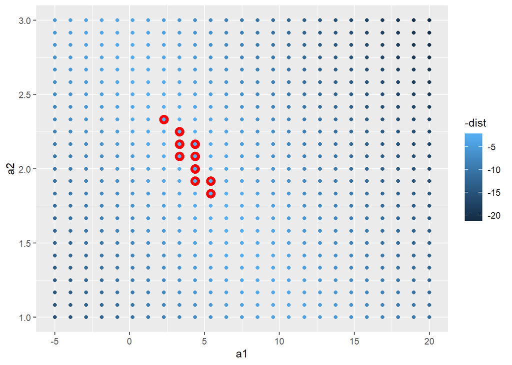

```r
grid %>%
  ggplot(aes(a1, a2)) +
  geom_point(
    data = filter(grid, rank(dist) <= 10),
    size = 4, colour = "red"
  ) +
  geom_point(aes(color = -dist))
```

- 다음 과 같이 원데이터에 최적의 10개 모델을 겹쳐 그리면 모두 잘 맞는 것처럼 보이다.

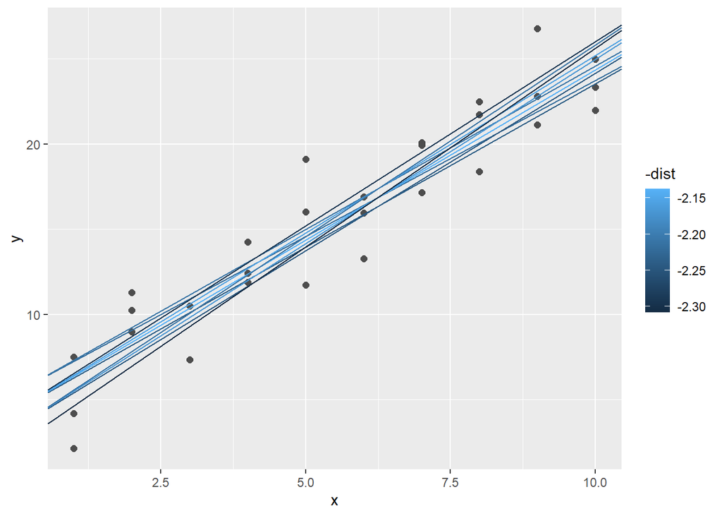

```r
ggplot(sim1, aes(x, y)) +
  geom_point(size = 2, color = "grey30") +
  geom_abline(
    aes(intercept = a1, slope = a2, color = -dist),
    data = filter(grid, rank(dist) <= 10)
  )
```

최적의 모델을 선택할 떄까지 그리드를 반복적으로 더욱 세밀하게 만드는 작업을 생각해볼 수있다. 하지만 이 문제를 해결할 수 있는 더 좋은 방법인 뉴턴 랩슨 기법이라 불리는 수치 최소화 도구가 있다. 이는 시작적을 선택하고 가장 가파른 기울기를 찾기 위해 탐색한다. 그런 다음 가장 작은 값으로 갈 수 없을 때까지 기울기를 약간씩 기울이는 작업을 반복한다. R에서는 optim()을 사용하여 이 작업을 수행 할 수 있다.

```r
best <- optim(c(0, 0), measure_distance, data = sim1)
```

```r
best$par
```

```
## [1] 4.222248 2.051204
```

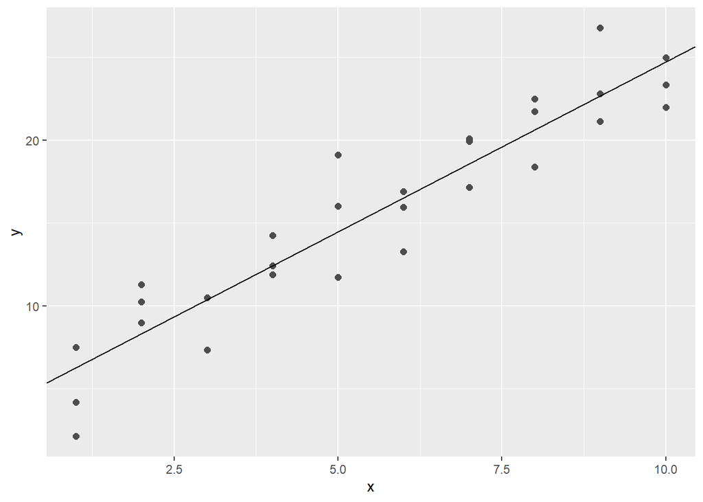

```r
ggplot(sim1, aes(x, y)) +
  geom_point(size = 2, color = "grey30") +
  geom_abline(intercept = best$par[1], slope = best$par[2])
```

optim()의 세부적인 작동 방식에 대해서는 고려하지 않아도 된다. 여기서 중요한 것은 바로 직관이다. 모델과 데이터셋 간의 차이를 정의하는 함수와 모델의 파라미터를 변경함에 따라 거리를 최소화할 수 있는 알고리즘이 있다면 최적의 모델을 찾을 수 있다. 이 접근법의 휼률한 점은 방정식을 작성할 수 있는 모든 모델 모음에 작동한다는 것이다.  
이 모델은 일반적인 모델 모음(즉, 신형 모델)의 특별한 경우이므로 이 모델에 적용할 수 있는 접근법이 한 가지 더 있다. 선형 모델은 `y = a_1 + a_2 * x_1 + a_3 * x_2 + ... + a_n * x_(n-1)`과 같은 일반적인 형식을 가진다. 따라서 이 간단한 모델은 n이 2이고 x_1이 x인 일반 선형 모델과 같다. `R에는 lm()이라는 선형 모델을 적합하기 위해 특별히 고안된 툴이 있다.` lm()에는 모델 집합을 지정하는 특별한 방법인 ‘수식’이 들어있다. 수식은 y ~ x와 같은 형태이며 lm()은 y =a_1 + a_2 * x와 같은 함수로 변환해준다. 다음과 같이 모델을 적합하여 결과를 확인할 수 있다.

```r
sim1_mod <- lm(y ~ x, data = sim1)
```

```r
coef(sim1_mod)
```

```
## (Intercept)           x
##    4.220822    2.051533
```

(coef: 모델링 함수에 의해 반환 된 객체에서 모델 계수를 추출하는 일반 함수입니다.)

위 값은 optim()을 사용해서 얻은 값과 정확히 일치하는 값이다. lm()의 이면에서는 optim()을 사용하지 않는 대신, 선형 모델의 수학적 구조의 이점을 사용한다. 기하학, 미적분학, 선형대수학 간의 연결을 기반으로 한 lm()은 정교한 알고리즘을 사용하여 개별 단계에서 가장 가까운 모델을 찾는다. 이 접근법은 더 빠르며 전체의 최솟값을 보장한다.

# **18.3 모델 시각화하기**

이전 절과 같은 간단한 모델의 경우, 모델 집합과 적합된 계수를 주의 깊게 살펴보면 모델이 포착하는 패턴을 파악할 수 있다. 모델링에 관한 통계 과정을 수강하게 된다면 이 작업을 수행하는 데 많은 시간을 할애하게 될 것이다. 그러나 여기서는 다른 방침을 취할 것이다. 즉, 모델의 예측값을 탐색함으로써 모델을 이해하는데 초점을 맞출 것이다. 이 방법은 큰 장점을 가지고 있다. 모든 유형의 예측 모델은 예측값을 생성하므로 모든 유형의 예측 모델을 이해하기 위해 같은 기법을 사용할 수 있다. 또한, 모델에서 포착하지 못한 것(데이터에서 예측값을 뺀 나머지 부분으로 흔히 잔차라고 함)을 확인할 때 유용하다. 잔차는 눈에 띄는 패턴을 제거하여 감지하기 어려운 나머지 추세를 분석할 수 있도록 해주므로 중요하다고 할 수 있다.

## **18.3.1 예측값**

모델의 예측값을 시각화하기 위해 데이터가 존재하는 영역을 포함하는 균일한 간격의 그리드를 생성한다. 가장 쉬운 방법은 modelr::data_grid()를 사용하는 것이다. 첫 번째 인수는 데이터프레임이며, 그다음 인수에 대해서는 고유한 값에 대한 모든 조합을 생성한다.

```r
grid <- sim1 %>%
  data_grid(x)
```

```r
grid
```

```
## # A tibble: 10 x 1
##        x
##    <int>
##  1     1
##  2     2
##  3     3
##  4     4
##  5     5
##  6     6
##  7     7
##  8     8
##  9     9
## 10    10
```

- 다음은 예측값을 추가한다. 데이터프레임과 모델을 인수로 갖는 modelr::add_predictions()을 사용한다. 이 함수는 모델의 예측값을 데이터 프레임의 새로운 열로 추가한다.

```r
grid <- grid %>%
  add_predictions(sim1_mod)
```

```r
grid
```

```
## # A tibble: 10 x 2
##        x  pred
##    <int> <dbl>
##  1     1  6.27
##  2     2  8.32
##  3     3 10.4
##  4     4 12.4
##  5     5 14.5
##  6     6 16.5
##  7     7 18.6
##  8     8 20.6
##  9     9 22.7
## 10    10 24.7
```

(또한, 이 함수를 사용하여 원 데이터셋에 예측값을 추가할 수 있다.) 다음으로 예측값을 플롯에 나타낸다. geom_abline()을 사용하는 것과 비교하였을 때 다음의 추가 진행 작업에 어ᄄᅠᆫ 차이점이 있는지 궁금할 것이다. 이 접근법의 장점은 가장 간단한 모델부터 복잡한 모델까지 R의 모든 모델에 동작한다는 것이다. 오직 시각화 기술에 의해서만 제한된다. 더 복잡한 모델 유형을 시각화 하는 방법에 대해 알고 싶다면 http://vita.had.co.nz/papers/model-vis.html 을 참고하자.

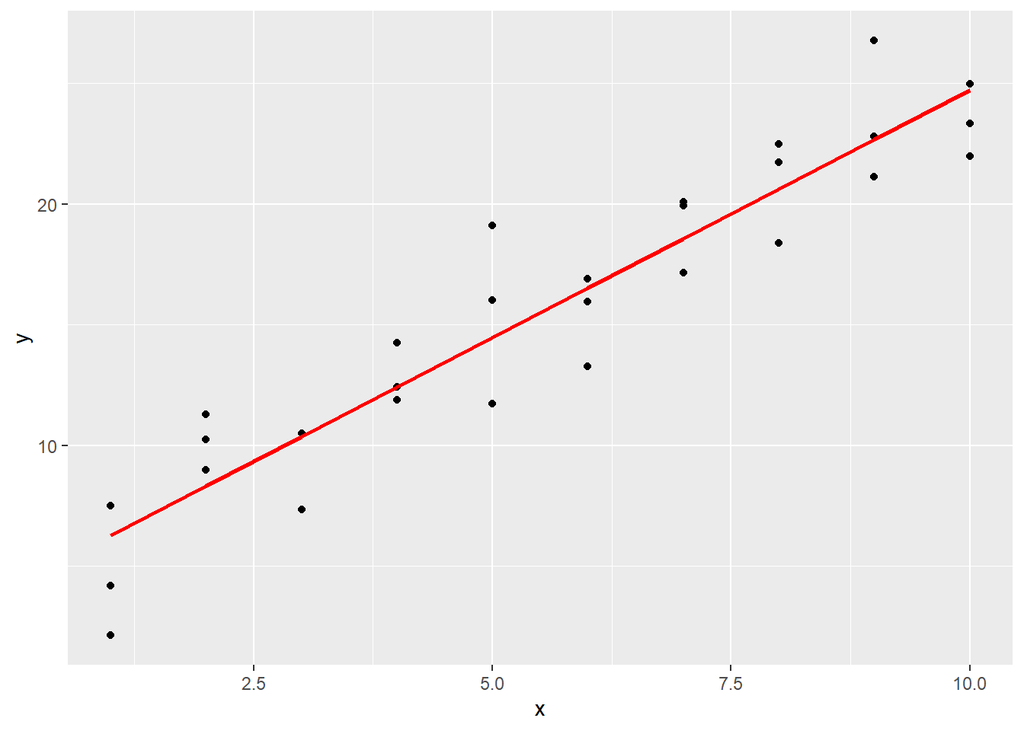

```r
ggplot(sim1, aes(x)) +
  geom_point(aes(y = y)) +
  geom_line(
    aes(y = pred),
    data = grid,
    colour = "red",
    size = 1
  )
```

## **18.3.2 잔차**

예측값의 다른 측면에는 잔차가 있다. 예측값은 모델이 포착한 패턴을 나타내고, 잔차는 모델이 놓친 것을 알려준다. 잔차는 이전에 계산한 예측값과 관측값 사이의 차이값이다.  
add_predictions()와 유사한 기능을 하는 add_residuals()을 사용해서 데이터에 잔차를 추가한다. `주의: 만들어진 그리드가 아니라 원래의 데이터셋을 사용한다. 이는 잔차를 계산하는데 실제 y값이 필요하기 때문이다.`

```r
sim1 <- sim1 %>%
  add_residuals(sim1_mod)
```

```r
sim1
```

```
## # A tibble: 30 x 3
##        x     y    resid
##    <int> <dbl>    <dbl>
##  1     1  4.20 -2.07
##  2     1  7.51  1.24
##  3     1  2.13 -4.15
##  4     2  8.99  0.665
##  5     2 10.2   1.92
##  6     2 11.3   2.97
##  7     3  7.36 -3.02
##  8     3 10.5   0.130
##  9     3 10.5   0.136
## 10     4 12.4   0.00763
## # ... with 20 more rows
```

잔차가 모델에 대해 전달해주는 것을 이해하기 위한 몇 가지 방법이 있다. 한 가지는 단순히 잔차의 분포를 이해할 수 있도록 하는 빈도 다각형을 그리는 것이다.

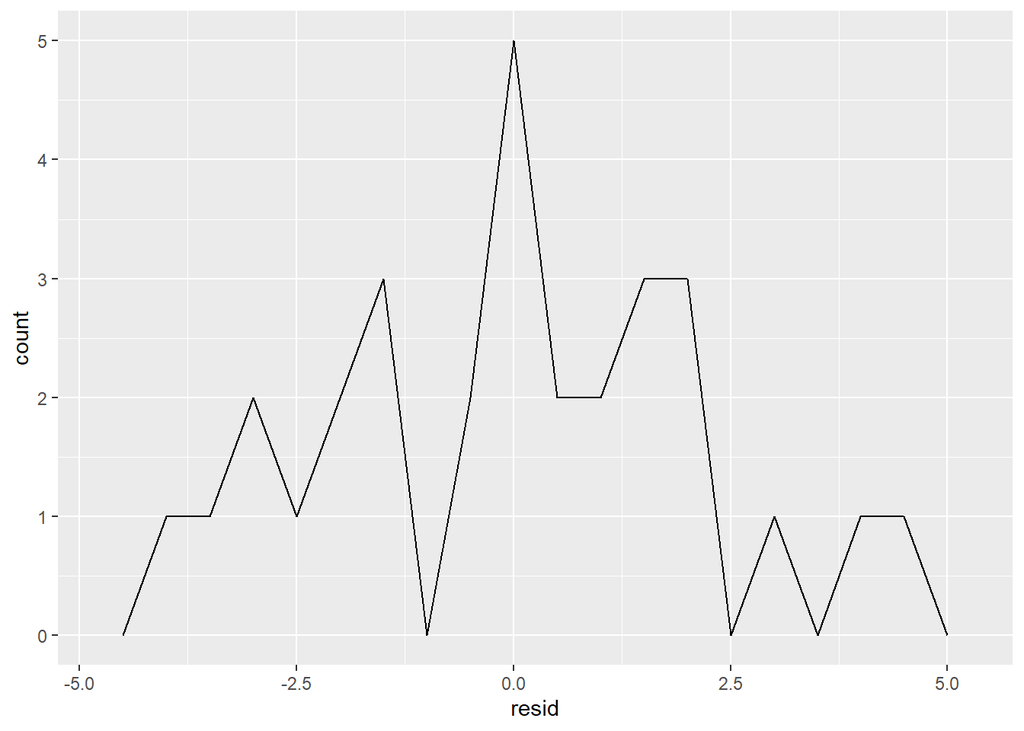

```r
ggplot(sim1, aes(resid)) +
  geom_freqpoly(binwidth = 0.5)
```

- 이는 모델의 품질을 보정하는 데 도움이 되며 다음과 같이 ‘관측값과 예측값이 얼마나 멀리 떨어져 있는가?’ 라는 질문에 답할 수 있다. 또한 `잔차의 평균값은 항상 0이다.`  
  본래의 예측 변수 대신 잔차를 사용하여 플롯을 다시 그리고 싶을 수도 있다. 다음 장에서 많은 부분을 확인하게 될 것이다.

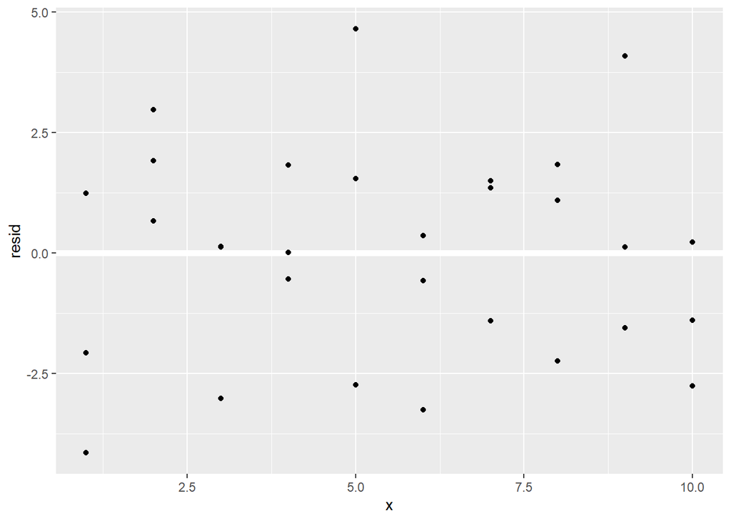

```r
ggplot(sim1, aes(x, resid)) +
  geom_ref_line(h = 0) +
  geom_point()
```

- 위 플롯은 랜덤한 잔차를 나타내며 이는 모델이 데이터셋에서 패턴을 잘 포착하였다는 것을 의미한다.

# **18.4 수식과 모델 모음**

이전에 facet_wrap()과 facet_grid()를 사용할 때 수식을 본 적이 있다. R에서 수식은 ‘특수한 동작’을 하도록 하는 일반적인 방법을 제공한다. 변수의 값을 즉시 평가하기보다는 함수에 의해 해석될 수 있도록 수식을 보유한다. R의 모델링 함수 대부분은 수식에서 함수로의 표준 전환을 사용한다. 이미 간단한 전환 한 가지는 보았다. y ~ x는 y = a_1 * a_2 * x로 전환된다. R에서 실제로 전환하는 것을 보고 싶다면 model_matrix() 함수를 이용할 수 있다. 데이터프레임과 수식을 이용하여 모델 방정식을 정의하는 티블을 반환한다. 출력값의 각열은 모델 하나의 계수와 연결되며 함수는 항상 y = a_1 * out1 + a_2 * out_2 형식이다. 가장 간단한 케이스인 y ~x1을 통해 흥미로운 사실을 알아본다.

```r
df <- tribble(
  ~y, ~x1, ~x2,
  4,2,5,
  5,1,6
)
```

```r
model_matrix(df, y ~ x1)
```

```
## # A tibble: 2 x 2
##   `(Intercept)`    x1
##           <dbl> <dbl>
## 1             1     2
## 2             1     1
```

R이 모델에 y절편을 추가하는 방법은 값이 1인 열을 추가하는 것이다. 기본적으로 R은 항상 1인 열을 추가한다. 만약 이를 원하지 않는다면 –1을 사용하여 제거해야 한다.

```r
model_matrix(df, y ~ x1 - 1)
```

```
## # A tibble: 2 x 1
##      x1
##   <dbl>
## 1     2
## 2     1
```

모델에 변수를 추가할 때마다 모델 매트릭스는 증가한다.

```r
model_matrix(df, y ~ x1 + x2)
```

```
## # A tibble: 2 x 3
##   `(Intercept)`    x1    x2
##           <dbl> <dbl> <dbl>
## 1             1     2     5
## 2             1     1     6
```

떄때로 이 수식의 표기법은 ‘월킨슨-로저스 표기법’이라고 불리며, 원킨슨과 로저스의 Symbolic Description of Factorial Models for Analysis of Variance에 처음 설명되었다. 모델링 대수학의 모든 세부사항을 이해하고 싶다면 원 논문을 자세히 읽어볼 가치가 있다. 다음 절에서는 이러한 수식 표기법이 범주형 변수, 상호작용 및 변형에 적용되는 방식을 설명한다.  
(논문링크 : https://www.jstor.org/stable/2346786?seq=1#page_scam_tab_contents)

## **18.4.1 범주형 변수**

수식에서 함수를 생성하는 것은 예측 변수가 연속형일 때는 간단하지만, 예측 변수가 범주형일 때는 조금 복잡해진다. y ~ sex(sex는 남성 혹은 여성을 나타내는 변수)와 같은 함수가 있다고 가정해보자. sex는 숫자가 아니어서 곱할 수 없으므로 y = x_0 + x_1 * sex와 같은 수식으로 변환하는 것은 맞지 않다. 대신 R은 수식을 y = x_0 + x_1 * sex_male로 변환하며 여기서 sex_male은 sex가 남성이면 1, 그렇지 않으면 0을 의미한다.

```r
df <- tribble(
  ~ sex, ~ response,
  "male", 1,
  "female", 2,
  "male", 1
)
```

```r
model_matrix(df, response ~ sex)
```

```
## # A tibble: 3 x 2
##   `(Intercept)` sexmale
##           <dbl>   <dbl>
## 1             1       1
## 2             1       0
## 3             1       1
```

왜 R이 sexfemale 열은 만들지 않는지 궁금할 것이다. 그렇게 하면 다른 열(즉, sexfemale = 1 – sexfemale)을 기반으로 완전히 예측할 수 있는 열을 만들게 되기 때문이다. 안타깝게도 이것이 왜 문제인지에 대한 정확한 세부 내용은 이 책의 범위를 벗어난다. 간략하게 말하자면 너무 유연한 모델 모음이 생성되어 데이터와 유사한 무한히 많은 모델을 생성하게 된다. 그렇지만 다행히 예측값을 시각화하는 데 초점을 맞추면 정확한 매개 변수화에 대해서 걱정할 필요가 없다. 구체적인 데이터와 모델에 대해 살펴보자. 다음과 같이 modelr의 sim2 데이터셋이 존재한다.

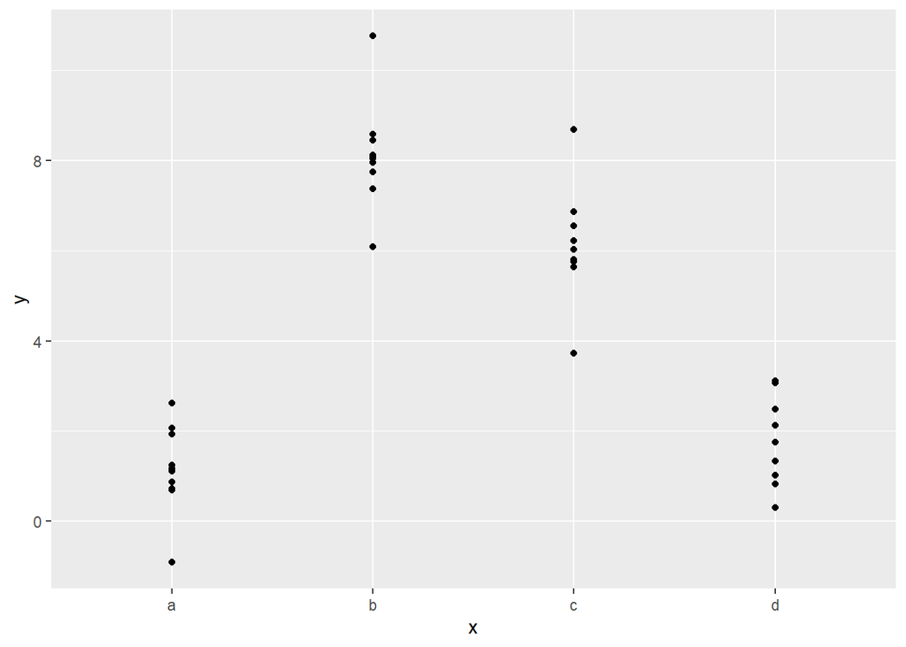

```r
ggplot(sim2) +
  geom_point(aes(x, y))
```

이 데이터에 대해 모델을 적합하고 예측값을 생성할 수 있다.

```r
mod2 <- lm(y ~ x, data = sim2)
```

```r
grid <- sim2 %>%
  data_grid(x) %>%
  add_predictions(mod2)
```

```r
grid
```

```
## # A tibble: 4 x 2
##   x      pred
##   <chr> <dbl>
## 1 a      1.15
## 2 b      8.12
## 3 c      6.13
## 4 d      1.91
```

사실상 범주형 변수 x를 포함한 모델은 각 범주의 평균값을 예측한다. (그 이유는 각 범주의 평균값이 평균제곱근 편차를 최소화하기 떄문이다.) 이는 원 데이터 위에 예측값을 겹쳐서 그려보면 쉽게 확인할 수 있다.

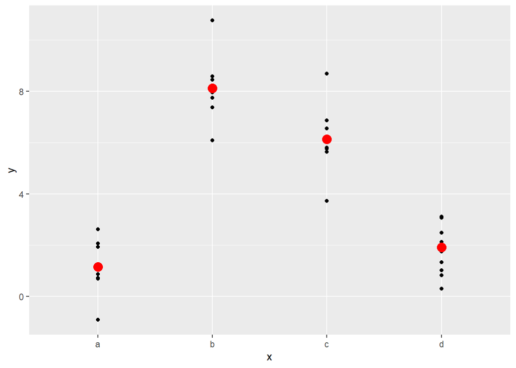

```r
ggplot(sim2, aes(x)) +
  geom_point(aes(y = y)) +
  geom_point(
    data = grid,
    aes(y = pred),
    color = "red",
    size=4
  )
```

관측하지 못한 값에 대해서는 예측할 수 없다. 실수로 이 작업을 수행하게 되면 다음과 같은 에러 메시지가 나타날 것이다.

```r
tibble(x = "e") %>%
  add_predictions(mod2)

Error in eval(predvars, data, env) : 객체 'x1'를 찾을 수 없습니다
```

## **18.4.2 연속형과 범주형 변수의 상호작용**

연속형 변수와 범주형 변수를 결합하면 어ᄄᅠᇂ게 되는가? sim3는 범주형 예측 변수와 연속형 예측 변수를 포함한 데이터셋이다. 이 변수들은 간단한 플롯으로 시각화할 수 있다.

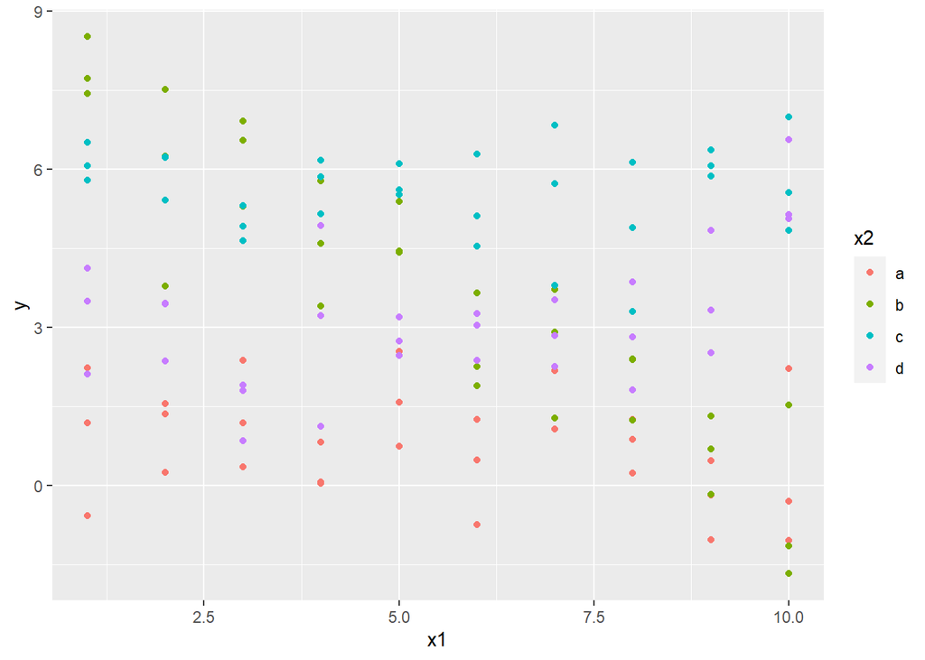

```r
ggplot(sim3, aes(x1, y)) +
  geom_point(aes(color = x2))
```

- 이 데이터에 적용할 수 있는 두 가지 모델이 있다.

```r
mod1 <- lm(y ~ x1 + x2, data = sim3)
```

```r
mod2 <- lm(y ~ x1 * x2, data = sim3)
```

`+를 사용하여 변수를 추가하면 모델은 다른 모든 변수와 독립적인 각 효과를 추정한다.` `*을 상용하면 상호작용이라 불리는 항을 적합할 수 있다`. 예를 들어 y ~ x1 * x2는 y = a_0 + a_1 * a1 + a_2 * a2 + a_12 * a1 * a2로 변환된다. *를 사용하면 상호작용과 개별 구성요소 모두 모델에 포함된다.

이 모델을 시각화하려면 새로운 두가지 수법이 필요하다.

- 두 개의 예측 변수에 대해 data_grid()를 적용해야 한다. 이 함수는 x1과 x2의 고유한 값에 대한 모든 조합을 생성한다.
- 두 모델로 동시에 예측값을 생성하기 위해서 행으로 각 예측값을 추가하는 gather_predictions()를 사용할 수 있다. gather_predictions()를 보완하는 함수는 각각의 예측값을 새로운 열로 추가하는 spread_predictions()이다.

위 함수를 함꼐 사용하면 다음과 같은 결과를 얻을 수 있다.

```r
grid <- sim3 %>%
  data_grid(x1, x2) %>%
  gather_predictions(mod1, mod2)
```

```r
grid
```

```
## # A tibble: 80 x 4
##    model    x1 x2     pred
##    <chr> <int> <fct> <dbl>
##  1 mod1      1 a      1.67
##  2 mod1      1 b      4.56
##  3 mod1      1 c      6.48
##  4 mod1      1 d      4.03
##  5 mod1      2 a      1.48
##  6 mod1      2 b      4.37
##  7 mod1      2 c      6.28
##  8 mod1      2 d      3.84
##  9 mod1      3 a      1.28
## 10 mod1      3 b      4.17
## # ... with 70 more rows
```

면분할을 사용해서 두 모델의 결과를 하나의 플롯에 시각화할 수 있다.

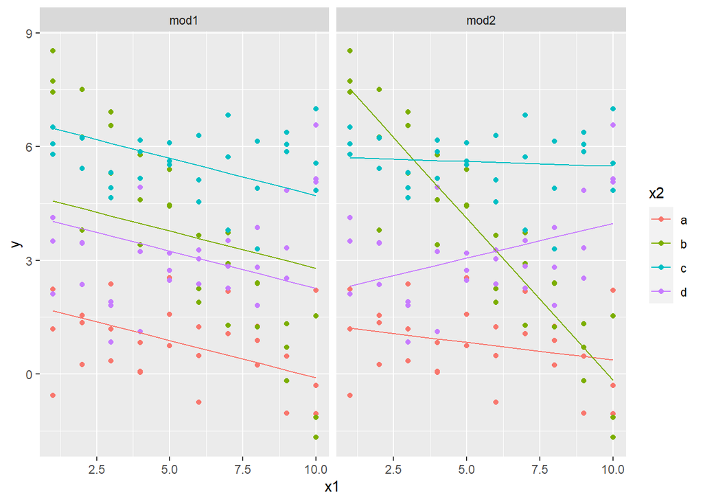

```r
ggplot(sim3, aes(x1, y, color = x2)) +
  geom_point() +
  geom_line(data = grid, aes(y = pred)) +
  facet_wrap(~ model)
```

+를 사용한 모델은 각 라인의 기울기는 같지만 y 절편값은 서로 다르다. *를 사용한 모델은 기울기와 y 절편값이 모두 다르다. 어떤 모델이 이 데이터에 잘 맞을까? 이는 잔차를 통해 확인할 수 있다. 여기서는 각 그룹 내의 패턴을 쉽게 확인하기 위해 모델과 x2로 면분할하였다.

```r
sim3 <- sim3 %>%
  gather_residuals(mod1, mod2)
```

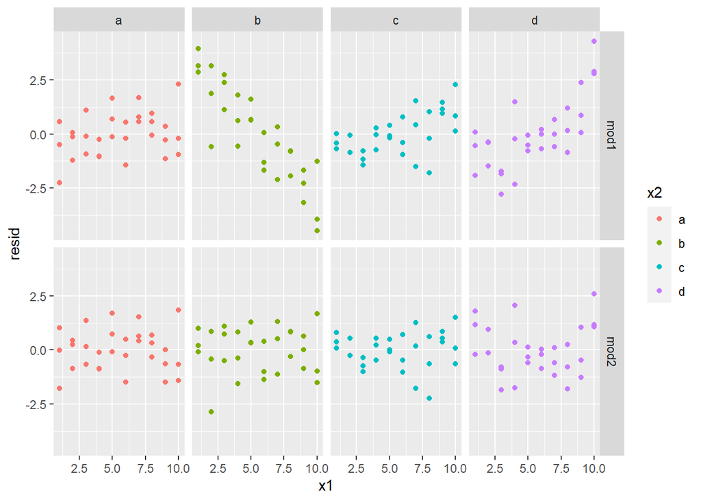

```r
ggplot(sim3, aes(x1, resid, color = x2)) +
  geom_point() +
  facet_grid(model ~ x2)
```

mod2의 잔차에서는 확실한 패턴이 거의 보이지 않는다. mod1의 잔차는 분명하게 모델 b에서 어떤 패턴을 놓쳤다는 것을 나타내주며 b보다는 덜하지만 c와 d에서도 여전히 패턴이 존재하는 것을 알 수 있다. mod1 또는 mod2 둘 중 어떤 모델이 더 좋은지 알 수 있는 정확한 방법이 있는지 궁금할 것이다. 다방면의 수학적 배경지식이 필요한 방법이 있긴 하지만 그 방법에 대해서는 고려하지 않을 것이다. 여기서는 모델이 관심 있는 패턴을 포착하였는지와 관련된 질적 평가에 집중할 것이다.

## **18.4.3 연속형 변수의 상호작용**

두 개의 연속 변수로 이루어진 같은 모델을 살표보자. 초반에는 이전 예제와 거의 유사하게 진행된다.

```r
mod1 <- lm(y ~ x1 + x2, data = sim4)
```

```r
mod2 <- lm(y ~ x1 * x2, data = sim4)
```

```r
grid <- sim4 %>%
  data_grid(
    x1 = seq_range(x1, 5),
    x2 = seq_range(x2, 5)
  ) %>%
  gather_predictions(mod1, mod2)
```

```r
grid
```

```
## # A tibble: 50 x 4
##    model    x1    x2   pred
##    <chr> <dbl> <dbl>  <dbl>
##  1 mod1   -1    -1    0.996
##  2 mod1   -1    -0.5 -0.395
##  3 mod1   -1     0   -1.79
##  4 mod1   -1     0.5 -3.18
##  5 mod1   -1     1   -4.57
##  6 mod1   -0.5  -1    1.91
##  7 mod1   -0.5  -0.5  0.516
##  8 mod1   -0.5   0   -0.875
##  9 mod1   -0.5   0.5 -2.27
## 10 mod1   -0.5   1   -3.66
## # ... with 40 more rows
```

data_grid() 안에 seq_range()를 사용한다. x의 고유한 모든 값을 사용하는 대신 최솟값과 최대값 사이를 균일하게 간격을 나눈 5개의 값을 사용할 것이다. 여기서는 이 부분이 매우 중요하지는 않지만, 일반적으로는 유용한 기법이다. seq_range() 함수에는 3개의 유용한 인수가 있다.

- pretty = TRUE는 ‘보기 좋은’ 시퀀스, 즉 사람의 눈에 보기 좋은 시퀀스를 생성한다. 이는 테이블로 결과물을 생성하려는 경우에 유용하다.

```r
seq_range(c(0.0123, 0.923423), n = 5)
```

```
## [1] 0.0123000 0.2400808 0.4678615 0.6956423 0.9234230
```

```r
seq_range(c(0.0123, 0.923423), n = 5, pretty = TRUE)
```

```
## [1] 0.0 0.2 0.4 0.6 0.8 1.0
```

- trim = 0.1은 꼬리 값의 10%를 제거한다. 변수가 꼬리가 긴 분포를 가지고 있으며, 중심 근처의 값을 생성하고자 하는 경우에 유용하다.

```r
x1 <- rcauchy(100)
```

(rcauchy = 위치 모수 위치 및 척도 모수 척도를 사용하여 코시 분포에 대한 밀도, 분포 함수, 분위 함수 및 임의 생성.)

```r
seq_range(x1, n = 5)
```

```
## [1] -27.951285  -6.123373  15.704539  37.532451  59.360363
```

```r
seq_range(x1, n = 5, trim = 0.10)
```

```
## [1] -5.244016 -1.021360  3.201297  7.423954 11.646611
```

```r
seq_range(x1, n = 5, trim = 0.25)
```

```
## [1] -2.6487892 -1.0918161  0.4651571  2.0221303  3.5791034
```

```r
seq_range(x1, n = 5, trim = 0.50)
```

```
## [1] -1.113011574 -0.560388585 -0.007765597  0.544857392  1.097480381
```

- expand = 0.1은 어떤 의미에서는 trim()의 반대이다. 즉, 범위를 10% 확장한다.

```r
x2 <- c(0, 1)
```

```r
seq_range(x2, n = 5)
```

```
## [1] 0.00 0.25 0.50 0.75 1.00
```

```r
seq_range(x2, n = 5, expand = 0.10)
```

```
## [1] -0.050  0.225  0.500  0.775  1.050
```

```r
seq_range(x2, n = 5, expand = 0.25)
```

```
## [1] -0.1250  0.1875  0.5000  0.8125  1.1250
```

```r
seq_range(x2, n = 5, expand = 0.50)
```

```
## [1] -0.250  0.125  0.500  0.875  1.250
```

다음으로 모델을 시각화해보자. 2개의 연속형 예측 변수를 가지고 있으므로 3D표면과 같은 모델을 상상해볼 수 있다. geom_tile()을 사용하여 이를 나타낼 수 있다.

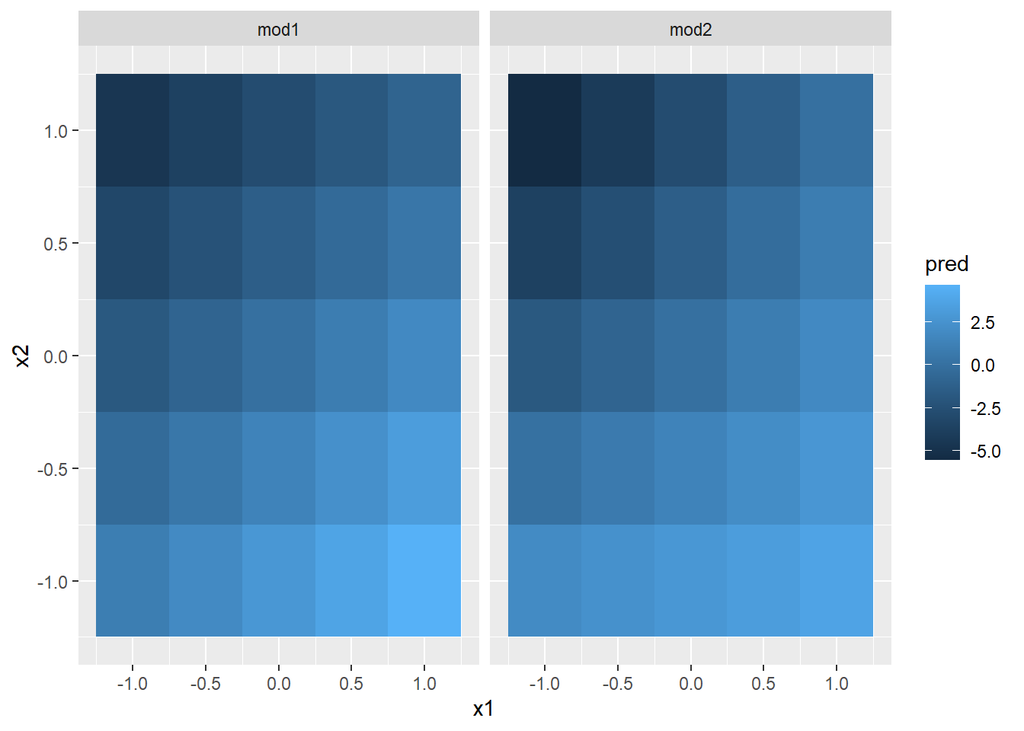

```r
ggplot(grid, aes(x1, x2)) +
  geom_tile(aes(fill = pred)) +
  facet_wrap(~ model)
```

위 플롯은 두 모델이 매우 다르지 않다는 것을 나타낸다. 하지만 어는 정도는 우리의 착각일 수 있다. 우리의 눈과 뇌는 색채의 농도를 정확하게 비교하는 데 그리 좋지 않다. 위에서부터 표면을 살펴보는 대신에 한 변수를 여러 조각으로 나누어 살펴볼 수 있다.

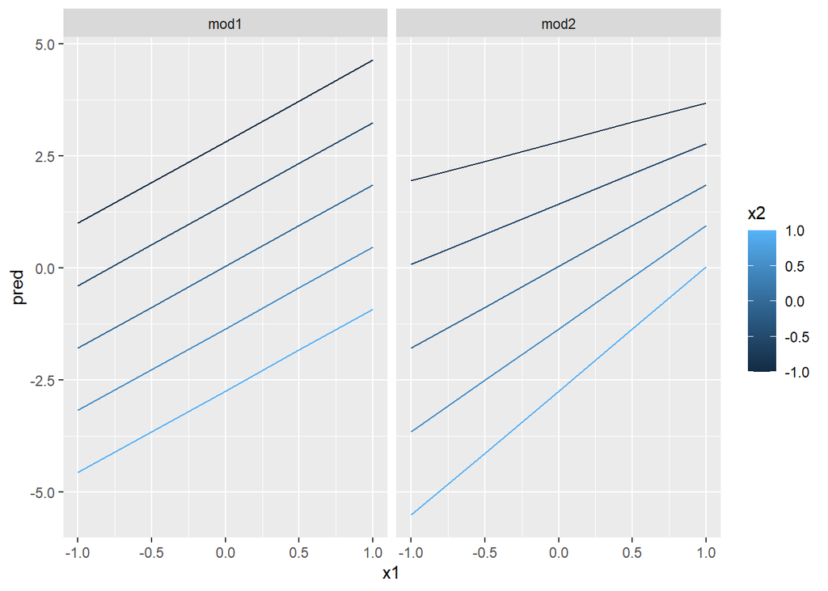

```r
ggplot(grid, aes(x1, pred, color = x2, group = x2)) +
  geom_line() +
  facet_wrap(~ model)
```

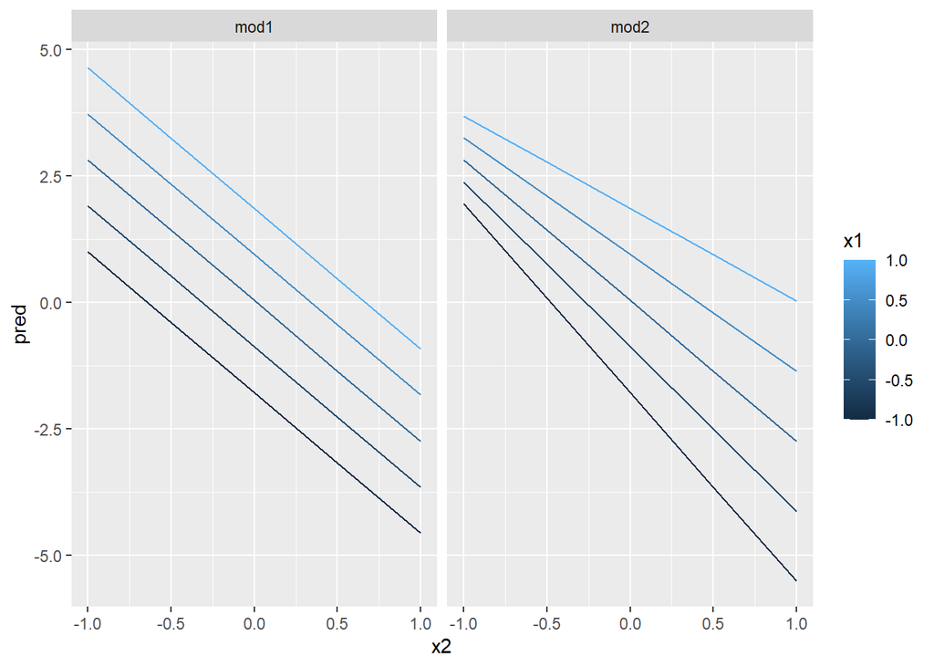

```r
ggplot(grid, aes(x2, pred, color = x1, group = x1)) +
  geom_line() +
  facet_wrap(~ model)
```

위 플롯은 두 개의 연속 변수 사이의 상호작용이 기본적으로 범주형과 연속형 변수의 상호작용과 같은 방식으로 동작함을 보여준다. 또한 이 플롯에서의 상호작용은 고정된 오프셋이 없다는 것을 나타낸다. 즉 y를 예측하기 위해서는 x1과 x2를 동시에 고려해야 한다. 단 두 개의 연속 변수만으로 좋은 시각화는 어렵다는 것을 알 수 있다. 하지만 그것은 합리적이다. 세 개 또는 그 이상의 변수들이 동시에 상호작용하는 방식에 대해서 이해하기가 쉬울 거라 예상하지는 않을 것이다. 다시 말하자면 모델을 탐색에 사용하면 시간을 조금 절약할 수 있고, 모델의 성능은 점점 개선할 수 있다. 모델은 완벽해야 할 필요가 없으며 단지 데이터를 더 잘 나타내는 데 도움을 주면 된다. ‘mod2가 mod1보다 더 좋은지’에 대해 확인해보기 위해 잔차를 탐색해보았다. 그 결과, 차이가 발생하기는 하지만 미묘하다. 연습문제에서 이를 확인해볼 수 있을 것이다.

## **18.4.4 변환**

모델의 수식 내에서 변환할 수도 있다. 예를 들어 log(y) ~ sqrt(x1) + x2는 y = a_1 + a_2 * x1 * sqrt(x) + a_3 * x2로 변환된다. 변환에 +, *, ^ 또는 -가 포함되어 있으면 R에서는 모델의 열거한 부분으로 처리하지 않게 하도록 I()로 묶어야 한다. 예를 들어 y ~ x + I(x ^ 2)은 y = a_1 + a_2* x +a_3 * x^2으로 변환된다. 만약 I()를 쓰지 않고 y ~ x ^ 2 + x로 명시한다면 R은 y ~ x * x + x로 계산할 것이다. x * x는 x자체의 상호작용을 의미한다. R은 자동으로 중복 변수를 제외하므로 x + x는 x가 되며 y ~ x ^ 2 + x는 y = a_1 + a_2 * x 함수가 된다. 이는 분석가가 의도한 것이 아니다. 다시 말하자면 모델이 변환되는 방식이 햇갈린다면 model_matrix()를 사용하여 lm()이 모델을 적합하는 수식이 무엇인지 정확하게 확인할 수 있다.

```r
df <- tribble(
  ~y, ~x,
  1, 1,
  2, 2,
  3, 3
)
```

```r
model_matrix(df, y ~ x^2 + x)
```

```
## # A tibble: 3 x 2
##   `(Intercept)`     x
##           <dbl> <dbl>
## 1             1     1
## 2             1     2
## 3             1     3
```

```r
model_matrix(df, y ~ I(x^2) + x)
```

```
## # A tibble: 3 x 3
##   `(Intercept)` `I(x^2)`     x
##           <dbl>    <dbl> <dbl>
## 1             1        1     1
## 2             1        4     2
## 3             1        9     3
```

변환은 비선형 함수를 근사하는 데 유용하게 사용할 수 있다. 만약 미적분 수업을 들었다면 ‘어떤 평활 함수도 다향식의 무한한 합으로 근사시킬 수 있다’라는 테일러 정리에 대해 들어봤을 것이다. 즉, y = a_1 + a_2 * x + a_3 * x^2 + a_4 * x ^ 3과 같은 방정식을 적합하여 선형 함수를 임의의 평활함수에 가갑게 만들 수 있다는 것을 의미한다. 손으로 시퀀스를 타이핑하는 것은 번거롭기 떄문에 R에서는 도우미 함수인 poly()를 제공한다.

```r
model_matrix(df, y ~ poly(x, 2))
```

```
## # A tibble: 3 x 3
##   `(Intercept)` `poly(x, 2)1` `poly(x, 2)2`
##           <dbl>         <dbl>         <dbl>
## 1             1     -7.07e- 1         0.408
## 2             1     -7.85e-17        -0.816
## 3             1      7.07e- 1         0.408
```

그러나 poly()를 사용하는 데는 한 가지 주요한 문제가 있다. 데이터의 범위를 벗어나면 다향식은 급격하게 양의 무한대 또는 음의 무한대로 발산하게 된다. 한 가지 안전한 대안은 본연의 스플라인(매끄러운 곡선)인 splins::ns()를 사용하는 것이다.

```r
library(splines)
```

```r
model_matrix(df, y ~ ns(x, 2))
```

```
## # A tibble: 3 x 3
##   `(Intercept)` `ns(x, 2)1` `ns(x, 2)2`
##           <dbl>       <dbl>       <dbl>
## 1             1       0           0
## 2             1       0.566      -0.211
## 3             1       0.344       0.771
```

비선형 함수를 근사할 때 어떻게 표현되는지 살표보자.

```r
sim5 <- tibble(
  x = seq(0, 3.5 * pi, length = 50),
  y = 4 * sin(x) + rnorm(length(x))
)
```

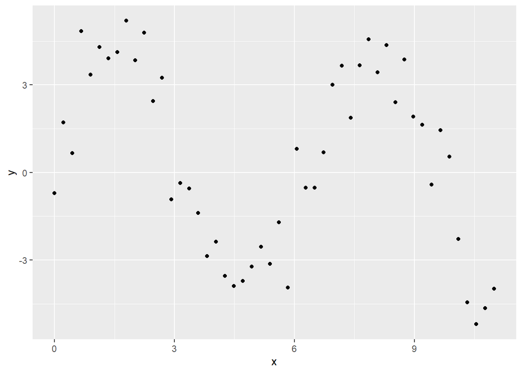

```r
ggplot(sim5, aes(x, y)) +
  geom_point()
```

이 데이터에 다섯 가지 모델을 적용해볼 것이다.

```r
mod1 <- lm(y ~ ns(x, 1), data = sim5)
```

```r
mod2 <- lm(y ~ ns(x, 2), data = sim5)
```

```r
mod3 <- lm(y ~ ns(x, 3), data = sim5)
```

```r
mod4 <- lm(y ~ ns(x, 4), data = sim5)
```

```r
mod5 <- lm(y ~ ns(x, 5), data = sim5)
```

```r
grid <- sim5 %>%
  data_grid(x = seq_range(x, n = 50, expand = 0.1)) %>%
  gather_predictions(mod1, mod2, mod3, mod4, mod5, .pred = "y")
```

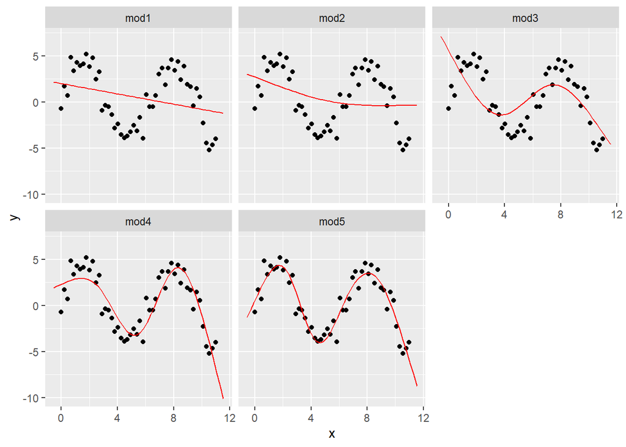

```r
ggplot(sim5, aes(x, y)) +
  geom_point() +
  geom_line(data = grid, color = "red") +
  facet_wrap(~ model)
```

데이터 범위를 벗어나 추정하는 것은 명백히 좋지 않다. 이는 다항식으로 함수를 근사하는 방법에서 좋지 않은 부분이지만, 모든 모델에서 발생할 수 있는 실질적인 문제이다. 데이터의 범위 밖에서 추정을 시작하면 변화하는 추정값이 맞는지에 대한 여부를 모델에서 알려줄 수 없다. 이론과 과학에 의존해야 한다.

# **18.5 결측값**

결측값은 변수 간의 관계에 대해 어떤 정보도 전달할 수 없으므로 모델링 함수는 결측값이 포함된 행을 삭제한다. R의 기본 동작은 자동으로 제거하는 것이지만 (전제조건에서 실행한) options(na.action = na.warn)은 경고문을 표시해준다.

```r
df <- tribble(
  ~x, ~y,
  1, 2.2,
  2, NA,
  3, 3.5,
  4, 8.3,
  NA, 10
)
```

```r
mod <- lm(y ~ x, data = df)
```

```r
경고메시지(들):
Dropping 2 rows with missing values
```

경고문을 표시하지 않으려면 na.action = na.exclude로 설정한다.

```r
mod <- lm(y ~ x, data = df, na.action = na.exclude)
```

nobs()를 사용하면 얼마나 많은 관측값이 사용되었는지 정확하게 알 수 있다.

```r
nobs(mod)
```

```
## [1] 3
```

# **18.6 다른 모델 모음**

이 장에서는 y = a_1 * x1 +a_2 * x2 + … + a_n * xn 형식으로 된 관계를 가정하는 선형 모델 종류에 대해서만 다룬다. 또한 이 책에서는 다루지 않았지만 선형 모형은 잔차가 정규분포를 따른다고 가정한다. 여러 흥미로운 방법으로 선형 모델을 확장한 모델의 종류는 다양하며 일부 모델을 다음에서 소개한다.

- 일반화 선형 모형: 예, stats::glm()  
  선형 모형에서는 반응 변수가 연속형이며 오차가 정규분포를 따른다고 가정한다. 일반화 선형 모형은 연속형이 아닌 반응 변수(예, 이항 데이터 또는 빈도수 데이터)를 포함할 수 있도록 선형 모형을 확장한다, 일반화 선형 모형은 우도의 통계적 아이디어를 기반으로 거리 메트릭을 정의하여 동작한다.
- 일반화 가법 모형: 예, mgcv::gam()  
  일반화 선형 모형을 확장하여 임의의 평활 함수를 포함하도록 한다. 즉, y = f(x) 형식의 방정식으로 변환되는 y ~ s(x) 형식의 수식을 작성한 후, gam()을 이용하여 그 함수가 무엇인지 추정한다. 이때 문제를 다루기 쉽게 만들기 위해 평활도를 제한조건으로 설정해야 한다.
- 벌점 선형 모형: 예, glmnet::glmnet()  
  복잡한 모델에 벌점을 부과하는 패널티 항을 (모수 백터와 원점 사이의 거리로 정의되는) 차이도에 추가한다. 이 방법은 같은 모집단의 새로운 데이터셋을 좀더 일반화할 수 있는 모델을 만드는 경향이 있다.
- 로버스트 선형 모형: 예, MASS:rlm()  
  매우 멀리 떨어져 있는 가중치가 적은 점과의 차이를 조정한다. 이 모형은 이상치가 없을 EO는 크게 효과가 없지만 이상값이 존재한다면 덜 민감하도록 만든다.
- 트리 모형: rpart::rpart()  
  선형 모형과 완전히 다른 방식으로 문제를 다룬다. 트리 모형은 데이터를 계속해서 작은 부분으로 분리하면 조각별 상수 모델을 적합한다. 트리 모형 그 자체로는 매우 효과적이지는 않지만 랜덤 포레스트(예, randomForest::randomForest())나 그레이디언트 부스팅(예, xgboost::xgboost)과 같은 모델로 결합하여 사용하면 매우 강력해 진다.

이 모델들은 프로그래밍 관점에서 모두 유사하게 동작한다. 일단 선형 모형을 완전히 익히고 나면 다른 모델 종류의 메커니즘을 쉽게 이해할 수 있다. 숙련된 모델러가 된다는 것은 몇 가지 괜찮은 원칙의 결합과 기법들이 담긴 큰 도구 상자를 가진다는 것이다. 이제 일반적인 도구와 한 가지의 유용한 모델 종류를 배웠으므로 다른 자료를 통해 더 많은 내용을 배울 수 있을 것이다.